# 5. Frequency - Hurdle - Poisson

```r
library(MASS)
library(lmtest)
library(pscl)
library(xgboost)
library(ggplot2)
library(caret)
```

```r
source('/home/kate/code/Utils/MyFunctions.R')
```

```r
ModelsDir <- '/home/kate/Research/Property/Models/'
UseSavedIfExists <- TRUE
```

```r
training_data <- read.csv("/home/kate/Research/Property/Data/property_wcf_training.csv", header=TRUE)
testing_data <- read.csv("/home/kate/Research/Property/Data/property_wcf_testing.csv", header=TRUE)
```

NB work with factors and because some numerical columns are factors (ordered) I convert them in factors explicitly. I may need to do this for some other columns which are Yes/No.

```r
training_data$appl_fail_3_blk <- as.factor( training_data$appl_fail_3_blk )
training_data$fixture_leak_3_blk <- as.factor( training_data$fixture_leak_3_blk )
training_data$pipe_froze_3_blk <- as.factor( training_data$pipe_froze_3_blk )
training_data$plumb_leak_3_blk <- as.factor( training_data$plumb_leak_3_blk )
training_data$rep_cost_3_blk <- as.factor( training_data$rep_cost_3_blk )
training_data$ustructure_fail_3_blk <- as.factor( training_data$ustructure_fail_3_blk )
training_data$waterh_fail_3_blk <- as.factor( training_data$waterh_fail_3_blk )
```

```r
testing_data$appl_fail_3_blk <- as.factor( testing_data$appl_fail_3_blk )
testing_data$fixture_leak_3_blk <- as.factor( testing_data$fixture_leak_3_blk )
testing_data$pipe_froze_3_blk <- as.factor( testing_data$pipe_froze_3_blk )
testing_data$plumb_leak_3_blk <- as.factor( testing_data$plumb_leak_3_blk )
testing_data$rep_cost_3_blk <- as.factor( testing_data$rep_cost_3_blk )
testing_data$ustructure_fail_3_blk <- as.factor( testing_data$ustructure_fail_3_blk )
testing_data$waterh_fail_3_blk <- as.factor( testing_data$waterh_fail_3_blk )
```

```r
max_yearbuilt <- max(training_data$yearbuilt)
max_sqft <- max(training_data$sqft)
max_water_risk_3_blk <- max(training_data$water_risk_3_blk)
max_water_risk_fre_3_blk <- max(training_data$water_risk_fre_3_blk)
max_water_risk_sev_3_blk <- max(training_data$water_risk_sev_3_blk)
```

```r
training_data$log_norm_yearbult <- log(training_data$yearbuilt/max_yearbuilt)
training_data$log_norm_sqft <- log(training_data$sqft/max_sqft)
training_data$log_norm_water_risk_3_blk <- log(training_data$water_risk_3_blk/max_water_risk_3_blk)
training_data$log_norm_water_risk_fre_3_blk <- log(training_data$water_risk_fre_3_blk/max_water_risk_fre_3_blk)
training_data$log_norm_water_risk_sev_3_blk <- log(training_data$sqft/max_water_risk_sev_3_blk)
```

```r
testing_data$log_norm_yearbult <- log(testing_data$yearbuilt/max_yearbuilt)
testing_data$log_norm_sqft <- log(testing_data$sqft/max_sqft)
testing_data$log_norm_water_risk_3_blk <- log(testing_data$water_risk_3_blk/max_water_risk_3_blk)
testing_data$log_norm_water_risk_fre_3_blk <- log(testing_data$water_risk_fre_3_blk/max_water_risk_fre_3_blk)
testing_data$log_norm_water_risk_sev_3_blk <- log(testing_data$sqft/max_water_risk_sev_3_blk)
```

```r
training_data$stories <- as.factor(training_data$stories)
training_data$units <- as.factor(training_data$units)
training_data$secondaryresidence <- as.factor(training_data$secondaryresidence)
training_data$sprinklersystem <- as.factor(training_data$sprinklersystem)
training_data$firealarmtype <- as.factor(training_data$firealarmtype)
training_data$waterdetectiondevice <- as.factor(training_data$waterdetectiondevice)
training_data$propertymanager <- as.factor(training_data$propertymanager)
training_data$cova_deductible <- as.factor(training_data$cova_deductible)
training_data$cova_limit       <- as.factor(training_data$cova_limit      )
training_data$waterded <- as.factor(training_data$waterded)
training_data$protectionclass <- as.factor(training_data$protectionclass)
training_data$fire_risk_model_score <- as.factor(training_data$fire_risk_model_score)
training_data$ordinanceorlawpct <- as.factor(training_data$ordinanceorlawpct)
training_data$functionalreplacementcost <- as.factor(training_data$functionalreplacementcost)
training_data$homegardcreditind <- as.factor(training_data$homegardcreditind)
training_data$landlordind <- as.factor(training_data$landlordind)
training_data$rentersinsurance <- as.factor(training_data$rentersinsurance)
training_data$burglaryalarmtype <- as.factor(training_data$burglaryalarmtype)
training_data$propertymanager <- as.factor(training_data$propertymanager)
```

```r
testing_data$stories <- as.factor(testing_data$stories)
testing_data$units <- as.factor(testing_data$units)
testing_data$secondaryresidence <- as.factor(testing_data$secondaryresidence)
testing_data$sprinklersystem <- as.factor(testing_data$sprinklersystem)
testing_data$firealarmtype <- as.factor(testing_data$firealarmtype)
testing_data$waterdetectiondevice <- as.factor(testing_data$waterdetectiondevice)
testing_data$propertymanager <- as.factor(testing_data$propertymanager)
testing_data$cova_deductible <- as.factor(testing_data$cova_deductible)
testing_data$cova_limit       <- as.factor(testing_data$cova_limit      )
testing_data$waterded <- as.factor(testing_data$waterded)
testing_data$protectionclass <- as.factor(testing_data$protectionclass)
testing_data$fire_risk_model_score <- as.factor(testing_data$fire_risk_model_score)
testing_data$ordinanceorlawpct <- as.factor(testing_data$ordinanceorlawpct)
testing_data$functionalreplacementcost <- as.factor(testing_data$functionalreplacementcost)
testing_data$homegardcreditind <- as.factor(testing_data$homegardcreditind)
testing_data$landlordind <- as.factor(testing_data$landlordind)
testing_data$rentersinsurance <- as.factor(testing_data$rentersinsurance)
testing_data$burglaryalarmtype <- as.factor(testing_data$burglaryalarmtype)
testing_data$propertymanager <- as.factor(testing_data$propertymanager)
```

```r
#unique numclaims values
numclaims <- unique(training_data$cova_ic_nc_water)
```

## Modeling

```r
formula_all <-  cova_ic_nc_water ~
log_norm_yearbult +
log_norm_sqft +
stories +
roofcd +
units +
occupancycd +
waterded +
protectionclass +
constructioncd +
#fire_risk_model_score +
#usagetype +
secondaryresidence +
ordinanceorlawpct +
functionalreplacementcost +
homegardcreditind +
sprinklersystem +
landlordind +
rentersinsurance +
firealarmtype +
burglaryalarmtype +
waterdetectiondevice +
propertymanager +
#cova_deductible +
cova_limit +
log_norm_water_risk_3_blk +
log_norm_water_risk_fre_3_blk +
#log_norm_water_risk_sev_3_blk +
appl_fail_3_blk +
fixture_leak_3_blk +
pipe_froze_3_blk +
plumb_leak_3_blk +
rep_cost_3_blk +
ustructure_fail_3_blk +
waterh_fail_3_blk
```

### Poisson models

```r
ModelFile <- paste(ModelsDir,"hurdlepoisson_all.rds",sep="")
if(file.exists(ModelFile) && UseSavedIfExists){
    hurdlepoisson_all <- readRDS(ModelFile)
    } else {
    hurdlepoisson_all <- hurdle(formula_all,  data = training_data,  offset=log_ecy,dist ="poisson",zero.dist = "poisson",link= "logit")
    saveRDS(hurdlepoisson_all, ModelFile)
    }
summary(hurdlepoisson_all)
```

```
Call:
hurdle(formula = formula_all, data = training_data, offset = log_ecy,
    dist = "poisson", zero.dist = "poisson", link = "logit")

Pearson residuals:
     Min       1Q   Median       3Q      Max
-0.25827 -0.11563 -0.09533 -0.07697 47.69662

Count model coefficients (truncated poisson with log link):
                                Estimate Std. Error z value Pr(>|z|)
(Intercept)                   -9.553e+00  3.380e+01  -0.283 0.777456
log_norm_yearbult              1.426e+01  1.042e+01   1.369 0.170906
log_norm_sqft                  3.091e-01  3.524e-01   0.877 0.380430
stories2                       1.038e-01  1.962e-01   0.529 0.596736
stories3                      -1.299e+01  8.069e+02  -0.016 0.987159
roofcdMEMBRANE                 4.324e-01  5.940e-01   0.728 0.466680
roofcdMETAL                   -1.411e+01  1.496e+03  -0.009 0.992475
roofcdOTHER                    1.725e-01  2.490e-01   0.693 0.488578
roofcdTAR                     -1.335e+00  1.022e+00  -1.307 0.191356
roofcdTILE                    -9.501e-03  1.881e-01  -0.051 0.959718
roofcdWOOD                    -1.446e+01  8.489e+02  -0.017 0.986406
units2                        -1.364e-01  6.009e-01  -0.227 0.820424
units3                         3.495e-01  6.383e-01   0.548 0.583969
units4                        -1.715e-01  5.798e-01  -0.296 0.767457
occupancycdTENANT             -2.266e-01  3.644e-01  -0.622 0.534001
waterded5000                  -1.361e+01  1.083e+03  -0.013 0.989974
waterded7500                  -3.266e+00  3.810e+01  -0.086 0.931676
waterded10000                 -5.249e+00  4.875e+01  -0.108 0.914255
protectionclass1              -1.407e-01  7.756e-01  -0.181 0.856056
protectionclass2              -6.678e-01  7.292e-01  -0.916 0.359753
protectionclass3              -5.476e-01  7.227e-01  -0.758 0.448650
protectionclass4              -5.916e-01  7.228e-01  -0.819 0.413068
protectionclass5              -3.888e-02  7.729e-01  -0.050 0.959883
protectionclass6              -8.568e-01  8.124e-01  -1.055 0.291560
protectionclass7              -1.356e+01  2.008e+03  -0.007 0.994613
protectionclass8              -5.731e+00  7.939e+01  -0.072 0.942453
protectionclass9              -1.322e+00  2.603e+03  -0.001 0.999595
protectionclass10             -6.184e+00  1.002e+02  -0.062 0.950807
constructioncdB                1.638e+00  5.326e-01   3.075 0.002103 **
constructioncdF               -1.017e-01  1.838e-01  -0.553 0.580219
```

[output cut: 164 more lines]

```
ustructure_fail_3_blk1         0.061469   0.112045   0.549 0.583273
ustructure_fail_3_blk2         0.132210   0.114368   1.156 0.247679
ustructure_fail_3_blk3        -0.105524   0.124551  -0.847 0.396862
ustructure_fail_3_blk4         0.027009   0.112193   0.241 0.809759
ustructure_fail_3_blk5        -0.004462   0.110312  -0.040 0.967733
waterh_fail_3_blk1             0.153615   0.043567   3.526 0.000422 ***
waterh_fail_3_blk2             0.094511   0.026827   3.523 0.000427 ***
waterh_fail_3_blk3             0.001891   0.043218   0.044 0.965094
waterh_fail_3_blk4             0.047039   0.064977   0.724 0.469106
waterh_fail_3_blk5             0.003693   0.092138   0.040 0.968028
---
Signif. codes:  0 '***' 0.001 '**' 0.01 '*' 0.05 '.' 0.1 ' ' 1

Number of iterations in BFGS optimization: 179
Log-likelihood: -5.317e+04 on 202 Df
```

when fire risk is added - kernel died, looks like to many predictors usagetype - all NANs secondaryresidence is Ok cova_deductible - all NANs log_norm_water_risk_sev_3_blk - Error in optim(fn = countDist, gr = countGrad, par = c(start$count, if (dist == : non-finite value supplied by optim Is the error related to a specific predictor or a "summarized" effect?

Normalization is needed to make the model work. I was not able to add into the model and test cova_deductible and log_norm_water_risk_sev_3_blk. It returns errors. usagetype returns NA in covariance matrix for some levels. Some predictors (like ordinanceorlawpct) are marked as significant but really it's a random component I feel.

```r
formula_sign <-  cova_ic_nc_water ~
log_norm_yearbult +
log_norm_sqft +
stories +
roofcd +
units +
waterded +
protectionclass +
constructioncd +
sprinklersystem +
landlordind +
firealarmtype +
cova_limit +
log_norm_water_risk_fre_3_blk +
appl_fail_3_blk +
fixture_leak_3_blk +
pipe_froze_3_blk +
plumb_leak_3_blk +
waterh_fail_3_blk
```

```r
ModelFile <- paste(ModelsDir,"hurdlepoisson_sign.rds",sep="")
if(file.exists(ModelFile) && UseSavedIfExists){
    hurdlepoisson_sign <- readRDS(ModelFile)
    } else {
    hurdlepoisson_sign <- hurdle(formula_sign,  data = training_data,  offset=log_ecy,dist ="poisson",zero.dist = "poisson",link= "logit")
    saveRDS(hurdlepoisson_sign, ModelFile)
    }
summary(hurdlepoisson_sign)
```

```
Call:
hurdle(formula = formula_sign, data = training_data, offset = log_ecy,
    dist = "poisson", zero.dist = "poisson", link = "logit")

Pearson residuals:
     Min       1Q   Median       3Q      Max
-0.25169 -0.11595 -0.09583 -0.07708 47.44414

Count model coefficients (truncated poisson with log link):
                                Estimate Std. Error z value Pr(>|z|)
(Intercept)                     -4.86432   24.80218  -0.196 0.844513
log_norm_yearbult                9.32513   10.15360   0.918 0.358406
log_norm_sqft                    0.18683    0.34298   0.545 0.585947
stories2                         0.15034    0.19307   0.779 0.436165
stories3                       -13.47389  959.05181  -0.014 0.988791
roofcdMEMBRANE                   0.36506    0.59219   0.616 0.537597
roofcdMETAL                    -13.12433 1010.54052  -0.013 0.989638
roofcdOTHER                      0.17839    0.23629   0.755 0.450260
roofcdTAR                       -1.25749    1.01131  -1.243 0.213712
roofcdTILE                       0.02332    0.18705   0.125 0.900803
roofcdWOOD                     -15.07423 1194.79967  -0.013 0.989934
units2                          -0.13832    0.59428  -0.233 0.815952
units3                           0.36815    0.62217   0.592 0.554036
units4                          -0.19648    0.55522  -0.354 0.723439
waterded5000                   -13.46006  994.31783  -0.014 0.989199
waterded7500                    -2.50407   31.54022  -0.079 0.936720
waterded10000                   -4.63935   34.40981  -0.135 0.892749
protectionclass1                -0.18233    0.77332  -0.236 0.813607
protectionclass2                -0.64126    0.72893  -0.880 0.379002
protectionclass3                -0.53935    0.72329  -0.746 0.455855
protectionclass4                -0.55284    0.72492  -0.763 0.445692
protectionclass5                -0.02203    0.77265  -0.029 0.977258
protectionclass6                -0.80039    0.81767  -0.979 0.327647
protectionclass7               -15.03879 3779.68063  -0.004 0.996825
protectionclass8                -6.34371  104.97996  -0.060 0.951815
protectionclass9                -1.16655 4360.37413   0.000 0.999787
protectionclass10               -6.40503  116.02899  -0.055 0.955978
constructioncdB                  1.26198    0.50660   2.491 0.012735 *
constructioncdF                 -0.10169    0.17887  -0.568 0.569704
constructioncdM                  1.02961    0.48891   2.106 0.035211 *
```

[output cut: 106 more lines]

```
plumb_leak_3_blk1              0.271433   0.166006   1.635 0.102032
plumb_leak_3_blk2              0.180569   0.181710   0.994 0.320358
plumb_leak_3_blk3              0.128201   0.176194   0.728 0.466850
plumb_leak_3_blk4              0.358395   0.167576   2.139 0.032460 *
plumb_leak_3_blk5              0.524825   0.169063   3.104 0.001907 **
waterh_fail_3_blk1             0.175223   0.040998   4.274 1.92e-05 ***
waterh_fail_3_blk2             0.106066   0.025883   4.098 4.17e-05 ***
waterh_fail_3_blk3             0.009240   0.042107   0.219 0.826317
waterh_fail_3_blk4             0.075419   0.062155   1.213 0.224977
waterh_fail_3_blk5             0.053614   0.088247   0.608 0.543488
---
Signif. codes:  0 '***' 0.001 '**' 0.01 '*' 0.05 '.' 0.1 ' ' 1

Number of iterations in BFGS optimization: 145
Log-likelihood: -5.322e+04 on 144 Df
```

Covariance matrix estimates are definetly better then in the complex model

## Model comparison

```r
lrtest(hurdlepoisson_sign,hurdlepoisson_all)
```

A anova: 2 × 5

|  | #Df <dbl> | LogLik <dbl> | Df <dbl> | Chisq <dbl> | Pr(>Chisq) <dbl> |
| --- | --- | --- | --- | --- | --- |
| 1 | 144 | -53220.55 | NA | NA | NA |
| 2 | 202 | -53165.75 | 58 | 109.5874 | 5.008976e-05 |

```r
vuong(hurdlepoisson_sign,hurdlepoisson_all)
```

```
Vuong Non-Nested Hypothesis Test-Statistic:
(test-statistic is asymptotically distributed N(0,1) under the
 null that the models are indistinguishible)
-------------------------------------------------------------
              Vuong z-statistic             H_A    p-value
Raw                  -5.4443796 model2 > model1 2.5993e-08
AIC-corrected         0.2907136 model1 > model2    0.38564
BIC-corrected        33.9381659 model1 > model2 < 2.22e-16
```

```r
models <- list("All Features" = hurdlepoisson_all,  "Sign Features"=hurdlepoisson_sign)
```

```r
#Log likelyhood for all the models and DF
Models_LogLik <- rbind(logLik = sapply(models, function(x) round(logLik(x), digits = 0)),
    Df = sapply(models, function(x) attr(logLik(x), "df")))
Models_LogLik
```

A matrix: 2 × 2 of type dbl

|  | All Features | Sign Features |
| --- | --- | --- |
| logLik | -53166 | -53221 |
| Df | 202 | 144 |

```r
#AIC
Models_AIC <- rbind(AIC = sapply(models, function(x) round(AIC(x), digits = 0)))
Models_AIC
```

A matrix: 1 × 2 of type dbl

|  | All Features | Sign Features |
| --- | --- | --- |
| AIC | 106736 | 106729 |

```r
#BIC
Models_BIC <- rbind(BIC = sapply(models, function(x) round(BIC(x), digits = 0)))
Models_BIC
```

A matrix: 1 × 2 of type dbl

|  | All Features | Sign Features |
| --- | --- | --- |
| BIC | 109106 | 108419 |

Smaller AIC (BIC) suggests a better model. The model with significant features has a smaller AIC and BIC then the model with all features.

### Coefficients means

```r
sapply(models, function(x) coef(x)[1:20])
```

A matrix: 20 × 2 of type dbl

|  | All Features | Sign Features |
| --- | --- | --- |
| count_(Intercept) | -9.552883493 | -4.86431971 |
| count_log_norm_yearbult | 14.263890096 | 9.32513182 |
| count_log_norm_sqft | 0.309109171 | 0.18682712 |
| count_stories2 | 0.103796449 | 0.15034020 |
| count_stories3 | -12.986247313 | -13.47388696 |
| count_roofcdMEMBRANE | 0.432395730 | 0.36505892 |
| count_roofcdMETAL | -14.113187432 | -13.12433174 |
| count_roofcdOTHER | 0.172480060 | 0.17839412 |
| count_roofcdTAR | -1.335201562 | -1.25749299 |
| count_roofcdTILE | -0.009501178 | 0.02331574 |
| count_roofcdWOOD | -14.464079186 | -15.07422870 |
| count_units2 | -0.136411995 | -0.13832285 |
| count_units3 | 0.349517925 | 0.36815319 |
| count_units4 | -0.171460062 | -0.19647523 |
| count_occupancycdTENANT | -0.226644231 | -13.46005562 |
| count_waterded5000 | -13.606757623 | -2.50406716 |
| count_waterded7500 | -3.266278748 | -4.63934541 |
| count_waterded10000 | -5.248595427 | -0.18232837 |
| count_protectionclass1 | -0.140688969 | -0.64126493 |
| count_protectionclass2 | -0.667800887 | -0.53935372 |

### Rootograms for Assessing Goodness of Fit of Probability...

```r
library(countreg)
```

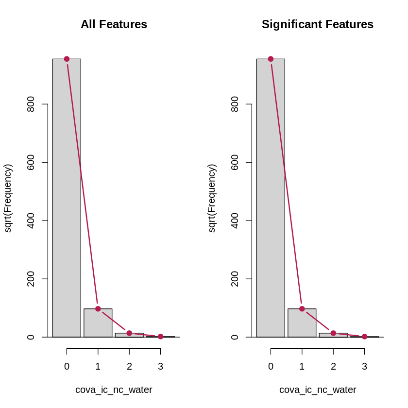

```r
par(mfrow = c(1, 2))
rootogram(hurdlepoisson_all,max = max(numclaims),main="All Features",style="hanging")
rootogram(hurdlepoisson_sign,max = max(numclaims),main="Significant Features",style="hanging")
```

The models look similar, without a deviance at number claims 2 point.

## Predicting Number of claims

I use XGB to predict the final result based on probabilities of number claims in each row.

```r
param0 <- list(
  "objective"  = "count:poisson"
  , "eval_metric" = "poisson-nloglik"
)
```

```r
#Adding  predicted probability values
#to training and testing dataset for each numclaims
#as separate column

training_all <- predict(hurdlepoisson_all, training_data, type='prob')
testing_all <- predict(hurdlepoisson_all, testing_data, type='prob')

training_sign <- predict(hurdlepoisson_sign, training_data, type='prob')
testing_sign <- predict(hurdlepoisson_sign, testing_data, type='prob')

for(unique_value in numclaims){

training_data[paste("hurdlepoisson_all", unique_value, sep = ".")] <- training_all[,as.numeric(unique_value)+1]
testing_data[paste("hurdlepoisson_all", unique_value, sep = ".")] <- testing_all[,as.numeric(unique_value)+1]

training_data[paste("hurdlepoisson_sign", unique_value, sep = ".")] <- training_sign[,as.numeric(unique_value)+1]
testing_data[paste("hurdlepoisson_sign", unique_value, sep = ".")] <- testing_sign[,as.numeric(unique_value)+1]

}
```

```r
#Features with probabilities listed by model
HP_all_features <- list();
HP_sign_features <- list();

i <- 1
for(unique_value in numclaims){
    HP_all_features[[i]] <- paste("hurdlepoisson_all", unique_value, sep = ".")
    HP_sign_features[[i]] <- paste("hurdlepoisson_sign", unique_value, sep = ".")

    i <- i + 1
}
```

```r
xgHP_all_training = xgb.DMatrix(as.matrix(training_data[,unlist(HP_all_features)]), label = training_data$cova_ic_nc_water)
setinfo(xgHP_all_training, "base_margin", log(training_data$ecy))

xgHP_all_testing = xgb.DMatrix(as.matrix(testing_data[,unlist(HP_all_features)]), label = testing_data$cova_ic_nc_water)
setinfo(xgHP_all_testing, "base_margin", log(testing_data$ecy))
```

TRUE

TRUE

```r
xgb = xgb.train(
  nrounds = 10000
  , params = param0
  , data = xgHP_all_training
)
training_data$hurdlepoisson_all = predict(xgb, xgHP_all_training)
testing_data$hurdlepoisson_all = predict(xgb, xgHP_all_testing)
```

```r
xgHP_sign_training = xgb.DMatrix(as.matrix(training_data[,unlist(HP_sign_features)]), label = training_data$cova_ic_nc_water)
setinfo(xgHP_sign_training, "base_margin", log(training_data$ecy))

xgHP_sign_testing = xgb.DMatrix(as.matrix(testing_data[,unlist(HP_sign_features)]), label = testing_data$cova_ic_nc_water)
setinfo(xgHP_sign_testing, "base_margin", log(testing_data$ecy))
```

TRUE

TRUE

```r
xgb = xgb.train(
  nrounds = 10000
  , params = param0
  , data = xgHP_sign_training
)
training_data$hurdlepoisson_sign = predict(xgb, xgHP_sign_training)
testing_data$hurdlepoisson_sign = predict(xgb, xgHP_sign_testing)
```

As an accuracy measure I use Normalized Weighted Gini:

```r
Testing_Gini <- data.frame ("All" = NormalizedWeightedGini(testing_data$cova_ic_nc_water,testing_data$hurdlepoisson_all,testing_data$ecy)
                   ,"Significant Only" = NormalizedWeightedGini(testing_data$cova_ic_nc_water,testing_data$hurdlepoisson_sign,testing_data$ecy)
                   )
Testing_Gini
```

A data.frame: 1 × 2

| All <dbl> | Significant.Only <dbl> |
| --- | --- |
| 0.2201532 | 0.2398513 |

Overall, the models are very close to each other. There is a difference in Normalized Weighted Gini which maybe significant and indicates Significant Features Only model is better.

### K Fold Validation

TBD Does not work with Caret very strightforward and my manual approach is wrong somewhere